# 6371: Final Exam Review

Matt Farrow

8/8/2020

Social media plays such a big role in advertising these days. Some individual social media influencers can make a living by accruing followers and then advertising on their accounts. Twitter is one such social media platform. A social media consultant is interested in determining how to **predict the number of Twitter followers** based on a few characteristics. He painstakingly scoured the internet to find several hundred Twitter accounts and recorded their number of followers (how many people follow their account-this is the money maker), followees (the number of people the influencer follows), the average number of tweets per week (collected over the course of a year), and the gender of the account holder. We don’t know much about how this data was collected. This data set is found in the file “Twitterdata.csv”.

- You may use SAS or R in your analyses.
- Please save your work in a Word document (preferably this one) with your NAME in the file name.
- Include your relevant output at the end of each response (or within, if appropriate).
- Include code in the appendix of your work.
- Unless otherwise specified, assume α=0.05 and 95% confidence.
- Be careful that software treats the variable gender as you intend, categorical or numeric. (Its values are 0 for a man and 1 for a woman.)

## Prep Data

```r
# Load data
df <- read_csv(here::here("6371", "week 15", "Twitterdata.csv"))
# Clean column names
df <- janitor::clean_names(df)

# Add gender label column & log followers
df <- df %>%
  mutate(sex = if_else(gender == 0, "M", "F"),
         log_followers = log(followers)) %>%
  rename(follow_ees = follow_e_es)

# Look at data
head(df)
```

```
## # A tibble: 6 x 6
##   followers follow_ees tweets_per_wk gender sex   log_followers
##       <dbl>      <dbl>         <dbl>  <dbl> <chr>         <dbl>
## 1         6         72             7      0 M              1.79
## 2      5359        127             2      1 F              8.59
## 3         9        129             1      0 M              2.20
## 4      3975        122             0      1 F              8.29
## 5         6         82             0      0 M              1.79
## 6       968         93            11      1 F              6.88
```

## Part A

The marketing consultant wishes to determine which variables (of those collected) are useful for predicting the number of Twitter followers for a given account.

- Consider the possibility that the relationship between followers and the explanatory variables (both tweets per week and number of followEES) can vary based on gender.
- No other interactions should be considered (besides those above).
- You will need to create a new variable that takes the log (base e) of the followers variable.

### Address All Assumptions

- Examine the assumptions with no transformations and after logging (base e) the number of followers.
- You should address any outliers, but do NOT delete any data points.
- After assumptions are discussed, proceed (using logged followers variable) as if all assumptions are met, even if they are not.

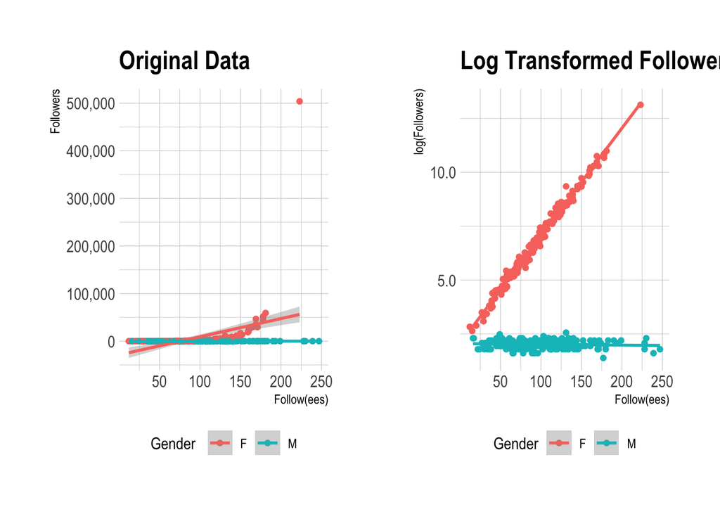

Scatter plots of data

```r
a <- df %>%
  ggplot(aes(follow_ees, followers, color = sex)) +
  geom_point() +
  geom_smooth(method = "lm") +
  scale_y_continuous(label = comma) +
  labs(title = "Original Data",
       x = "Follow(ees)",
       y = "Followers",
       color = "Gender ") +
  theme_ipsum() +
  theme(legend.position = "bottom")

b <- df %>%
  ggplot(aes(follow_ees, log_followers, color = sex)) +
  geom_point() +
  geom_smooth(method = "lm") +
  scale_y_continuous(label = comma) +
  labs(title = "Log Transformed Followers",
       x = "Follow(ees)",
       y = "log(Followers)",
       color = "Gender") +
  theme_ipsum() +
  theme(legend.position = "bottom")

# Combine plots
a + b
```

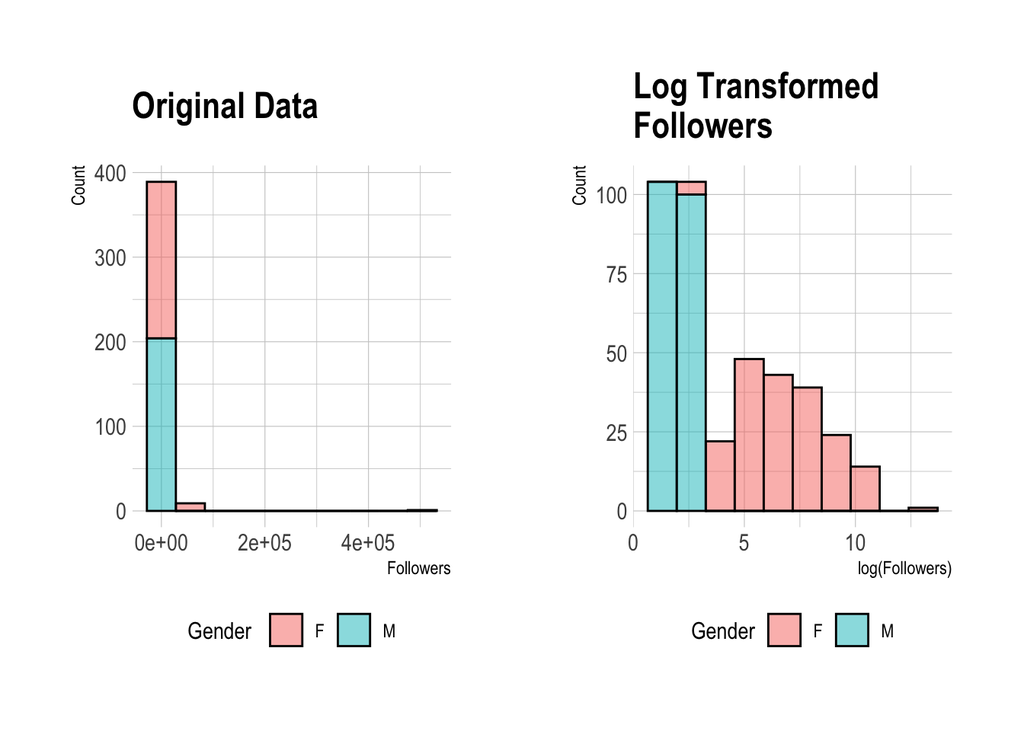

Histograms of data

```r
a <- df %>%
  ggplot(aes(followers, fill = sex)) +
  geom_histogram(bins = 10, color = "black", alpha = 0.5) +
  labs(title = "Original Data",
       x = "Followers",
       y = "Count",
       fill = "Gender ") +
  theme_ipsum() +
  theme(legend.position = "bottom")

b <- df %>%
  ggplot(aes(log_followers, fill = sex)) +
  geom_histogram(bins = 10, color = "black", alpha = 0.5) +
  scale_y_continuous(label = comma) +
  labs(title = "Log Transformed\nFollowers",
       x = "log(Followers)",
       y = "Count",
       fill = "Gender") +
  theme_ipsum() +
  theme(legend.position = "bottom")

# Combine plots
a + b
```

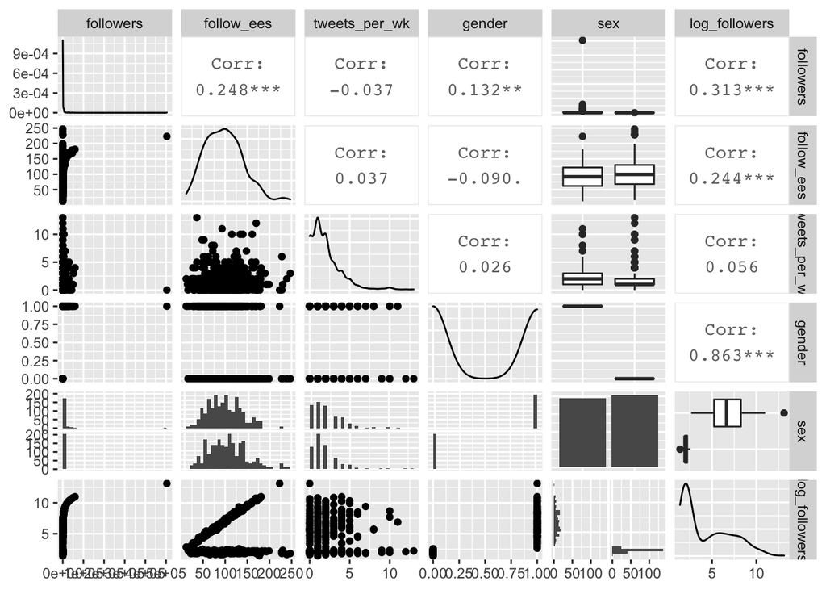

Plot Matrix

```r
ggpairs(df)
```

### Regression Model

Build the regression model with parameters to answer the question of interest (Don’t plug in estimates/values of βi’s yet.)

$$μ_{log(followers)} = β_0 + β_1(followees) + β_2(tweets\_per\_week) + β_3(gender) + β_4(gender * followees) + β_5(gender * tweets\_per\_week)$$

### Software Output

Copy and paste the typical software output that includes the beta estimates, p-values for each beta, and confidence interval, etc. for each beta (screenshot of a table should suffice).

```r
model <-
  lm(
    log_followers ~
      follow_ees + tweets_per_wk + gender + (gender * follow_ees) + (gender * tweets_per_wk),
    data = df
  )

summary(model)
```

```
##
## Call:
## lm(formula = log_followers ~ follow_ees + tweets_per_wk + gender +
##     (gender * follow_ees) + (gender * tweets_per_wk), data = df)
##
## Residuals:
##      Min       1Q   Median       3Q      Max
## -0.59949 -0.11717 -0.01021  0.14894  0.73396
##
## Coefficients:
##                        Estimate Std. Error t value Pr(>|t|)
## (Intercept)           2.0420790  0.0356216  57.327   <2e-16 ***
## follow_ees           -0.0003549  0.0003005  -1.181   0.2384
## tweets_per_wk         0.0065159  0.0063657   1.024   0.3067
## gender                0.0334582  0.0515339   0.649   0.5166
## follow_ees:gender     0.0503451  0.0004633 108.664   <2e-16 ***
## tweets_per_wk:gender -0.0164576  0.0094114  -1.749   0.0811 .
## ---
## Signif. codes:  0 '***' 0.001 '**' 0.01 '*' 0.05 '.' 0.1 ' ' 1
##
## Residual standard error: 0.1922 on 393 degrees of freedom
## Multiple R-squared:  0.9951, Adjusted R-squared:  0.9951
## F-statistic: 1.61e+04 on 5 and 393 DF,  p-value: < 2.2e-16
```

[output not shown]

[output not shown]

### Analysis of Leverage

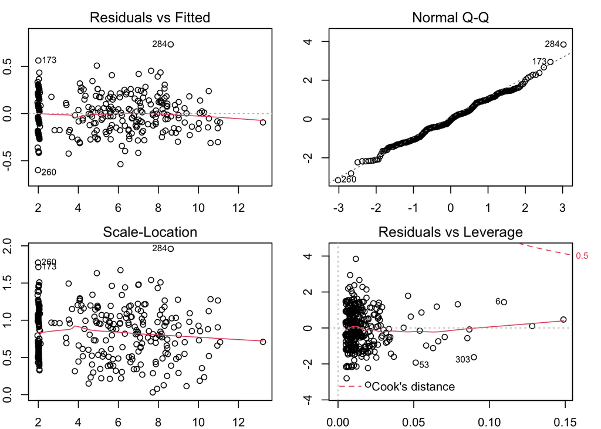

```r
# Change the layout to 2x2 to accommodate all plots
par(mfrow=c(2,2))
par(mar = rep(2, 4))

# Diagnostic Plots
plot(model)
```

#### Analysis of Residuals

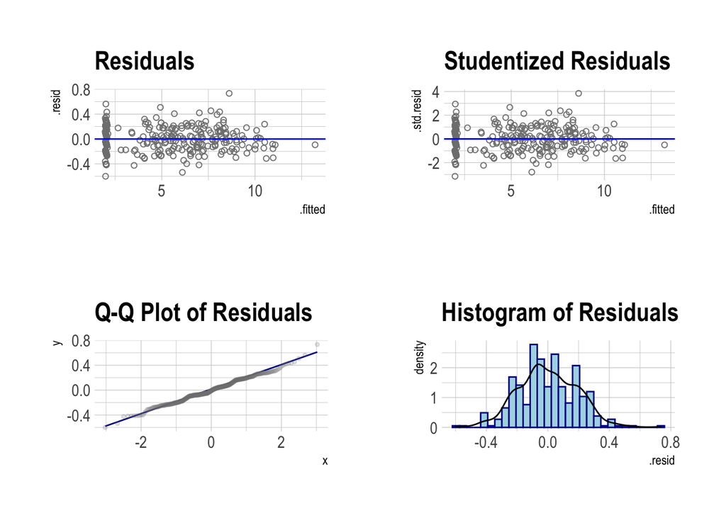

```r
# Plot residuals
a <- model_fit %>%
  ggplot(aes(.fitted, .resid)) +
  geom_point(shape = 1, color = "gray50") +
  geom_hline(yintercept = 0, color = "blue") +
  labs(title = "Residuals") +
  theme_ipsum()

# Plot studentized residuals
b <- model_fit %>%
  ggplot(aes(.fitted, .std.resid)) +
  geom_point(shape = 1, color = "gray50") +
  geom_hline(yintercept = 0, color = "blue") +
  labs(title = "Studentized Residuals") +
  theme_ipsum()

# Q-Q Plot of Residuals
c <- model_fit %>%
  ggplot(aes(sample = .resid)) +
  stat_qq_line(color = "darkblue") +
  stat_qq(alpha = 0.2, size = 1, color = "gray50") +
  labs(title = "Q-Q Plot of Residuals") +
  theme_ipsum()

# Histogram of residuals
d <- model_fit %>%
  ggplot(aes(.resid, ..density..)) +
  geom_histogram(fill = "lightblue", color = "darkblue") +
  geom_density() +
  labs(title = "Histogram of Residuals") +
  theme_ipsum()

(a + b) / (c + d)
```

#### Cook’s D

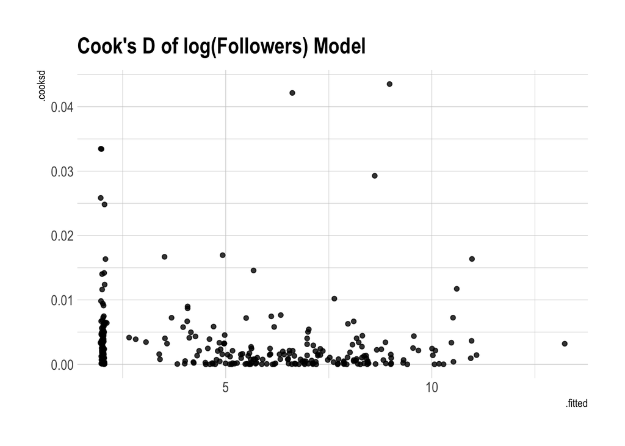

Cook’s D

```r
model_fit %>%
  ggplot(aes(.fitted, .cooksd)) +
  geom_jitter(alpha = 0.8) +
  labs(title = "Cook's D of log(Followers) Model") +
  theme_ipsum()
```

### Model Interpretaion

Fill out the following table. For the final column, interpret the coefficients as if all coefficients in the model are significant.

[output not shown]

### Rebuild Model

Rebuild the regression model, taking into account the p-values found when fitting the full model above (regression equation with parameters –GENERAL betas—this may be different or the same as question A-2)

$$μ_{log(followers)} = β_0 + β_1(followees) + β_2(gender) + β_3(gender * followees)$$

## Bonus

Build Your Own ANOVA (lack of fit test) that compares a model that predicts followers based on the three independent variables in the dataset (no interaction terms) to the model found in A-4. If these are exactly the same, state that. If not, build your own ANOVA.

$H_0: β_4 = β_5 = 0$ $H_a: β_4 or β_5 ≠ 0$

### Build Reduced Model

```r
model_reduced <- lm(log_followers ~ gender + follow_ees + tweets_per_wk, data = df)
```

### Run ANOVAs

```r
anova(model)
```

```
## Analysis of Variance Table
##
## Response: log_followers
##                       Df  Sum Sq Mean Sq    F value  Pr(>F)
## follow_ees             1  177.28  177.28  4801.1289 < 2e-16 ***
## tweets_per_wk          1    6.61    6.61   178.8963 < 2e-16 ***
## gender                 1 2351.36 2351.36 63680.7487 < 2e-16 ***
## follow_ees:gender      1  436.48  436.48 11821.0961 < 2e-16 ***
## tweets_per_wk:gender   1    0.11    0.11     3.0579 0.08113 .
## Residuals            393   14.51    0.04
## ---
## Signif. codes:  0 '***' 0.001 '**' 0.01 '*' 0.05 '.' 0.1 ' ' 1
```

```r
anova(model_reduced)
```

```
## Analysis of Variance Table
##
## Response: log_followers
##                Df  Sum Sq Mean Sq  F value Pr(>F)
## gender          1 2223.20 2223.20 1946.680 <2e-16 ***
## follow_ees      1  310.69  310.69  272.047 <2e-16 ***
## tweets_per_wk   1    1.35    1.35    1.185  0.277
## Residuals     395  451.11    1.14
## ---
## Signif. codes:  0 '***' 0.001 '**' 0.01 '*' 0.05 '.' 0.1 ' ' 1
```

```r
build_own_anova <- function(full, reduced){

  library(dplyr)

  # Get df and sum of squares from full model
  full <- full %>%
    anova() %>%
    slice_tail(1) %>%
    select(1:2)

  # Get df and sum of squares from reduced model
  reduced <- reduced %>%
    anova() %>%
    slice_tail(1) %>%
    select(1:2)

  # Create empty tibble
  byo_anova <- tibble(
    "source" = character(),
    "df" = numeric(),
    "SS" = numeric(),
    "MS" = numeric(),
    "F" = numeric(),
    "P-Value" = numeric()
  )

  # Label rows
  byo_anova[1,1] <- "Model"
  byo_anova[2,1] <- "Error"
  byo_anova[3,1] <- "Total"

  # Copy ANOVA values for df
  byo_anova[3,2] <- reduced$Df
  byo_anova[2,2] <- full$Df
  byo_anova[1,2] <- byo_anova$df[3] - byo_anova$df[2]

  # Copy ANOVA values for sum of squares
  byo_anova[3,3] <- reduced$`Sum Sq`
  byo_anova[2,3] <- full$`Sum Sq`
  byo_anova[1,3] <- byo_anova$SS[3] - byo_anova$SS[2]

  # Calculate MS
  byo_anova[2,4] <- byo_anova$SS[2] / byo_anova$df[2]
  byo_anova[1,4] <- byo_anova$SS[1] / byo_anova$df[1]

  # Calculate F
  byo_anova[1,5] <- byo_anova$MS[1] / byo_anova$MS[2]

  # Calculate P-value
  byo_anova[1,6] <- pf(byo_anova$F[1], byo_anova$df[2], byo_anova$df[1], lower.tail = FALSE)

  byo_anova
}

byo <- build_own_anova(model, model_reduced)
```

```r
byo %>%
  kable() %>%
  kable_styling("striped")
```

| source | df | SS | MS | F | P-Value |
| --- | --- | --- | --- | --- | --- |
| Model | 2 | 436.59658 | 218.2982888 | 5912.077 | 0.0001691 |
| Error | 393 | 14.51118 | 0.0369241 | NA | NA |
| Total | 395 | 451.10776 | NA | NA | NA |